# Individual Project

Tyler Lin

2023-04-17

# Introduction

In this project I wanted to predict the winner of the 2023 NBA Finals. To do this I will use 2 different methods to predict who will win.

Method 1: Use data analysis on the past few NBA finals and identify which stats are the most important in winning a game. Reference the leaders in these categories to determine the winner of the series.

Method 2: Look at the head to head stats of the teams and predict the winner off that.

After using both methods I will briefly observe the differences in the predictions.

# Data Analysis

```r
# Libraries
library(tidyverse)
```

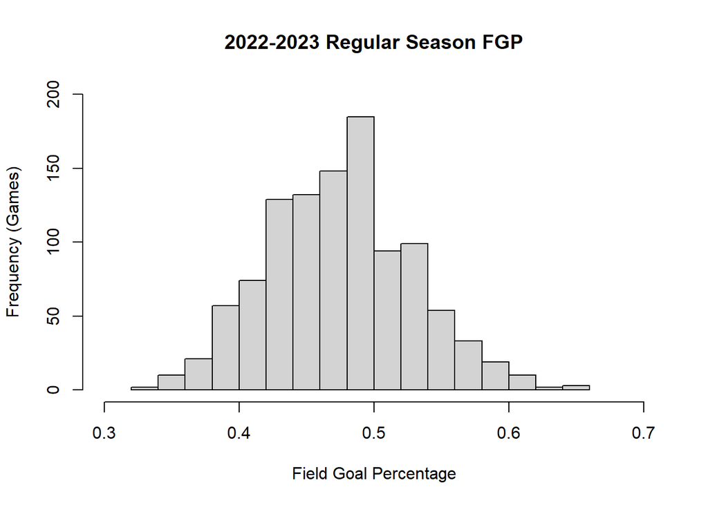

```r
library(ggplot2)

# Extract Data
champion <- read.csv("championsdata.csv")
statLeader <- read.csv("StatLeaders.csv")
games <- read.csv("nba_games.csv")

# Change Variables to Factors
champion$Year <- factor(champion$Year)
statLeader$Team <- factor(statLeader$Team)
games$winning_team <- factor(games$winning_team)

# Clear NA
statLeader <- na.omit(statLeader)


# Visualizing Data
# Note: Due to the large amounts of data used. Only certain ones have been chosen to be visualized. Process remains the same.
regular_fgp <- c(games$home_fg_pct, games$away_fg_pct)
champ_fgp <- c(champion$CFGP, champion$RFGP)

hist(regular_fgp, xlim = c(0.3, 0.7), ylim = c(0,200), ylab = "Frequency (Games)", xlab = "Field Goal Percentage",
     main = "2022-2023 Regular Season FGP")
```

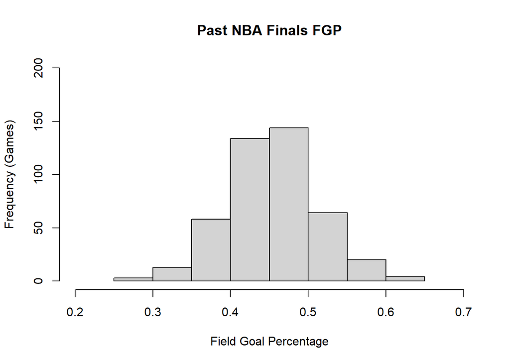

```r
hist(champ_fgp, xlim = c(0.2, 0.7), ylim = c(0, 200), ylab = "Frequency (Games)", xlab = "Field Goal Percentage",
     main = "Past NBA Finals FGP")
```

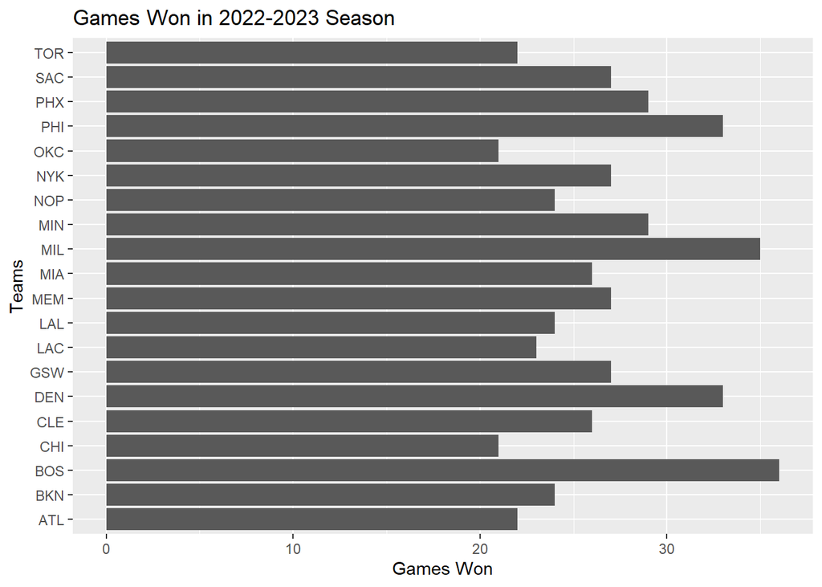

```r
ggplot(games, aes(winning_team)) + geom_bar() + coord_flip() + labs(title = "Games Won in 2022-2023 Season", y = "Games Won", x = "Teams")
```

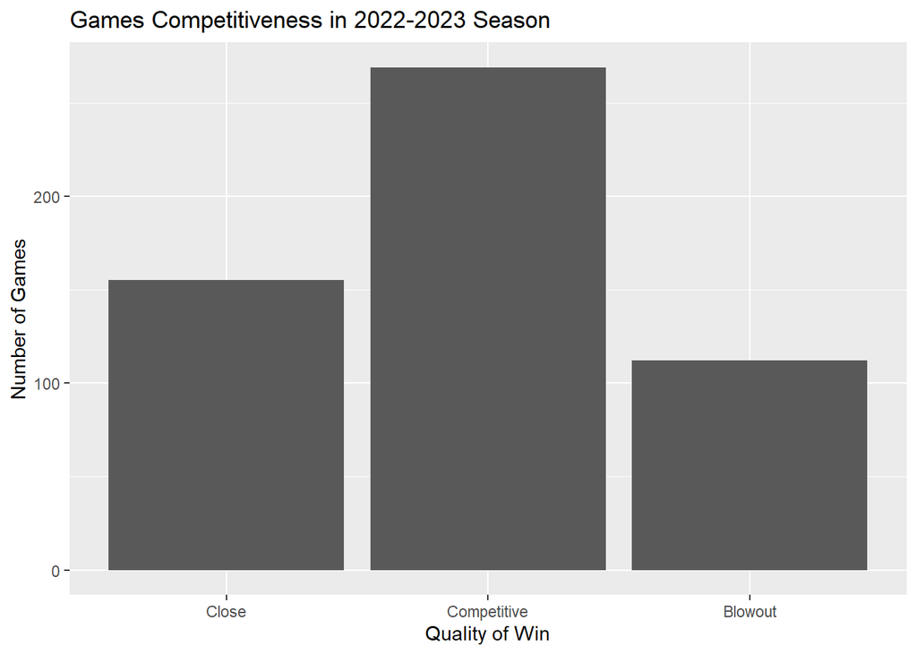

```r
# Filter Add Relevant Data
games <- games %>%
 select(home_team_short, home_points, away_team_short, away_points, winning_team) %>%
 mutate_if(is.character, factor) %>%
 mutate(pointDiff = abs(home_points - away_points), homeWon = home_team_short == winning_team) %>%
 mutate(blowout = cut(pointDiff, breaks = c(0, 5, 15, Inf), labels = c("Close", "Competitive", "Blowout")))


ggplot(games, aes(blowout)) + geom_bar() + labs(title = "Games Competitiveness in 2022-2023 Season", y = "Number of Games", x = "Quality of Win")
```

# Method 1

```r
# Determine which variables have an impact on winning
champion <- champion %>%

  # Gather means
  group_by(Year) %>%
  summarise(CPTS = mean(CPTS), CAST = mean(CAST), CBLK = mean(CBLK), CSTL = mean(CSTL), CFGP = mean(CFGP), CFTP = mean(CFTP), CTPP = mean(CTPP), CORB = mean(CORB), CDRB = mean(CDRB), RPTS = mean(RPTS), RAST = mean(RAST), RBLK =  mean(RBLK), RSTL = mean(RSTL), RFGP = mean(RFGP), RFTP = mean(RFTP), RTPP = mean(RTPP), RORB = mean(RORB), RDRB = mean(RDRB)) %>%
  mutate_if(is.double, round, digits = 2) %>%

  # Find Difference Between Variables
  group_by(Year) %>%
  summarise(Points = CPTS - RPTS, Assists = CAST - RAST, Blocks = CBLK - RBLK, Steals = CSTL - RSTL, FieldGoal = CFGP - RFGP, FreeThrow = CFTP - RFTP, ThreePoint = CTPP - RTPP, ORebound = CORB - RORB, DRebound = CDRB - RDRB) %>%

  # If positive, it made an impact on who became champion, else it didn't
  mutate_if(is.double, cut, breaks = c(-Inf, 0, Inf), labels = c("No", "Yes")) %>%
  select(!Year)

# See Results
summary(champion)
```

```
##  Points   Assists  Blocks   Steals   FieldGoal FreeThrow ThreePoint ORebound
##  No : 8   No :14   No :15   No :15   No :14    No :22    No :14     No :19
##  Yes:31   Yes:25   Yes:24   Yes:24   Yes:25    Yes:17    Yes:25     Yes:20
##  DRebound
##  No :14
##  Yes:25
```

From this we can see a connection with all of the variables with the exception of Free Throws and Offensive Rebounding. So by filtering out the unnecessary categories and summing by teams, the highest value should be this methods favorite to win.

Note: Record and Seed were added to the sum. This is because if you had a good record you did better during the regular season, thus you should be more favored. As for Seed, Research shows that almost all NBA winners come from the top 2 seeds, so it would make sense to add them into the equation too.

```r
# Collect Total Points and Compare
statLeader %>%
  select(-FTP, -ORB) %>%
  mutate(Total = rowSums(statLeader[,4:12])) %>%
  select(Team, Total) %>%
  arrange(desc(Total)) %>%
  head()
```

```
##   Team Total
## 1  BOS    98
## 2  PHI    98
## 3  DEN    94
## 4  GSW    92
## 5  SAC    86
## 6  BKN    81
```

# Method 2

```r
# Create a function that filters head to heads between teams and determines who should win, home advantage, and upset potential
headToHead <- function(x, y) {

  # Filter only X vs Y games
  h <- games %>%
    filter(home_team_short == x | away_team_short == x, home_team_short == y | away_team_short == y)

  # Games Played (Useful for all for loops)
  gp <- seq_along(h$winning_team)

  # X chances of winning against Y
  upset <- 0.5

  # Who beat who more
  if(length(which(h$winning_team == x)) > length(which(h$winning_team == y))) upset <- upset + 0.025
  else if (length(which(h$winning_team == x)) < length(which(h$winning_team == y))) upset <- upset - 0.025


  # X and Y home advantage strength
  xhome <- 0
  yhome <- 0

  # Simple Algorithm to determine home advantage strength
  for (i in gp) {
    hWon = h$homeWon[i]
    blow <- h$blowout[i]

    if (h$home_team_short[i] == x) {
      if (hWon & blow == "Blowout") xhome <- xhome + 2
      else if (hWon) xhome <- xhome + 1
      else if (!hWon & blow == "Blowout") x <- xhome - 1

    } else {
      if (hWon & blow == "Blowout") yhome <- yhome + 2
      else if (hWon) yhome <- yhome + 1
      else if (!hWon & blow == "Blowout") y <- yhome - 1
    }
  }

  # Who has a stronger home advantage
  if(xhome > yhome) upset <- upset + 0.025
  else if (xhome < yhome) upset <- upset - 0.025


  # Simple Algorithm to adjust the upset probability of X vs Y
  for (i in gp) {
    if (h$winning_team[i] == x & h$blowout[i] == "Competitive") upset <- upset + 0.05
    else if (h$winning_team[i] == x & h$blowout[i] == "Blowout") upset <- upset + 0.1
    else if (h$winning_team[i] == y & h$blowout[i] == "Competitive") upset <- upset - 0.05
    else if (h$winning_team[i] == y & h$blowout[i] == "Blowout") upset <- upset - 0.1
  }

  # Final Return
  upset
}


# Function to determine the favorite in the match up
fav <- function(x, y) {
  z <- headToHead(x,y)
  if (z == 0.5) "Even. High Seed Advance"
  else if (z > 0.5) x
  else y
}


# Simulation Function (Upsets Possible)
sim <- function(x, y) {
  z <- headToHead(x,y)
  s <- sample(0:1, size = 11, prob = c(1-z, z), replace = TRUE)
  if (sum(s) > 5) x
  else y
}
```

```r
# Run Through the Bracket to determine who will win (favorite)
fav("MIL", "MIA") # Milwaukee Advance
fav("CLE", "NYK") # New York Advance
fav("PHI", "BKN") # Philadelphia Advance
fav("BOS", "ATL") # Boston Advance
fav("DEN", "MIN") # Minnesota Advance
fav("PHX", "LAC") # Phoenix Advance
fav("SAC", "GSW") # Warriors Advance
fav("MEM", "LAL") # Lakers Advance

# Conference Semifinals
fav("MIL", "NYK") # Milwaukee Advance
fav("PHI", "BOS") # Boston Advance
fav("MIN", "PHX") # Phoenix Advance
fav("GSW", "LAL") # Lakers Advance

# Conference Finals
fav("MIL", "BOS") # Boston Advance
fav("PHX", "LAL") # Phoenix Advance

# Grand Finals
fav("BOS", "PHX") # Boston Wins NBA Finals


# Run Through the Bracket to determine who will win (simulation)
# Since there is so many outside factors why not leave it up to chance
set.seed(4576) # Random Seed

# ROUND 1
sim("MIL", "MIA") # Milwaukee Advance
sim("CLE", "NYK") # New York Advance
sim("PHI", "BKN") # Philadelphia Advance
sim("BOS", "ATL") # Boston Advance
sim("DEN", "MIN") # Denver Advance
sim("PHX", "LAC") # Phoenix Advance
sim("SAC", "GSW") # Sacramento Advance
sim("MEM", "LAL") # Memphis Advance

# Confrence Semifinals
sim("MIL", "NKY") # Milwaukee Advance
sim("PHI", "BOS") # Boston Advance
sim("DEN", "PHX") # Denver Advance
sim("SAC", "MEM") # Memphis Advance

# Confrence Finals
sim("MIL", "BOS") # Boston Advance
sim("DEN", "MEM") # Denver Advance

# Grand Finals
sim("BOS", "DEN") # Boston Wins NBA Finals
```

[output not shown]

# Conclusion

# References

2023 NBA Category Leaders: https://www.teamrankings.com/nba/stat/points-per-game

2023 NBA Bracket: http://www.espn.com/nba/bracket

2023 Regular Season Game Stats: https://www.kaggle.com/datasets/ethanchen44/nba-playoff-predictions

Past Finals Stats: https://www.kaggle.com/datasets/daverosenman/nba-finals-team-stats?select=runnerupsdata.csv

Finals Winners By Seed: https://nbahoopsonline.com/History/Leagues/NBA/playoffs/BestfinishbySeed.html

Note: Data sets were manipulated for my data analysis